# DS 202 Final Project Proposal

Jesse Dolan, Bela Banegas, Jennifer Godbersen

2024-05-07

## Introduction

With the ubiquity of technology in our everyday lives and the growing ability to extract large amounts of data from it, companies’ and governments’ interest in utilizing consumer data has grown. As a result, the fairly recent field of data science has become a hot topic. Data science is an attractive field for analytical thinkers who enjoy problem-solving, discovering insights, presenting findings, and enjoying the touted benefits of the field (flexibility in modality, growing job market). As students hoping to pursue careers in data science, we were interested in learning recent trends in data science salaries in order to be fully informed when looking for our first full-time jobs.

The main question we were looking to answer is: What variables affect data science salaries?

To attempt to answer this, we explored six different research questions: - RQ1: How have data science salaries overall changed over time? - RQ2: How does company size affect salary? - RQ3: How does company location affect salary? - RQ4: How does experience level affect salary? - RQ5: How does job title affect salary? - RQ6: How does remote ratio (in-person, hybrid, or remote) affect salary? Does this relationship appear to be different for companies of different sizes?

```r
file_path <- "salaries.csv"

df <- read.csv(file_path)

head(df)
```

```
##   work_year experience_level employment_type            job_title salary
## 1      2024               MI              FT         AI Architect 800000
## 2      2023               EN              FT Data DevOps Engineer  44382
## 3      2024               EN              FT         Data Analyst  40100
## 4      2024               EN              FT         Data Analyst  28069
## 5      2024               SE              FT        Data Engineer 220000
## 6      2024               SE              FT        Data Engineer 137500
##   salary_currency salary_in_usd employee_residence remote_ratio
## 1             USD        800000                 CA          100
## 2             EUR         47918                 NL           50
## 3             EUR         44555                 LT            0
## 4             EUR         31187                 LT            0
## 5             USD        220000                 US            0
## 6             USD        137500                 US            0
##   company_location company_size
## 1               CA            M
## 2               NL            L
## 3               LT            M
## 4               LT            M
## 5               US            M
## 6               US            M
```

```r
empty_rows <- df[!complete.cases(df), ]
if (any(is.na(df))) {
  print("There are NA values in the dataframe.")
} else {
  print("There are no NA values in the dataframe.")
}
```

```
## [1] "There are no NA values in the dataframe."
```

## Data

Variables include: year, experience level, employment type (full-time, part-time, contract, freelance), job title, salary, salary currency, salary in usd, employee residence, remote ratio (amount of work done remotely), and company location.

```r
file_path <- "salaries.csv"

df <- read.csv(file_path)

head(df)
```

```
##   work_year experience_level employment_type            job_title salary
## 1      2024               MI              FT         AI Architect 800000
## 2      2023               EN              FT Data DevOps Engineer  44382
## 3      2024               EN              FT         Data Analyst  40100
## 4      2024               EN              FT         Data Analyst  28069
## 5      2024               SE              FT        Data Engineer 220000
## 6      2024               SE              FT        Data Engineer 137500
##   salary_currency salary_in_usd employee_residence remote_ratio
## 1             USD        800000                 CA          100
## 2             EUR         47918                 NL           50
## 3             EUR         44555                 LT            0
## 4             EUR         31187                 LT            0
## 5             USD        220000                 US            0
## 6             USD        137500                 US            0
##   company_location company_size
## 1               CA            M
## 2               NL            L
## 3               LT            M
## 4               LT            M
## 5               US            M
## 6               US            M
```

```r
empty_rows <- df[!complete.cases(df), ]
if (any(is.na(df))) {
  print("There are NA values in the dataframe.")
} else {
  print("There are no NA values in the dataframe.")
}
```

```
## [1] "There are no NA values in the dataframe."
```

Data cleaning steps:

There are no empty rows, columns, or NA values at all. We didn’t need to sort anything out because we included all necessary sorting inside of our visualization steps.

## Variables

work_year -> (2020-2024)

experience_level -> (This includes values such as Entry-Level and Senior)

job_title -> (Includes a range of different job titles in the field)

salary -> (Salary in currency of the country the job is in)

salary_currency -> (The type of currency the salary is in)

salary_in_usd -> (The salary number in USD)

remote_ratio -> (Either 0, 50, or 100, for In-person, Hybrid, and Remote respectively)

company_location -> (Company location by country)

company_size -> (Company size, either S, M or L)

There was a lack of information on the Kaggle site and https://ai-jobs.net/ about what qualifies as a small, medium, or large company.

## Results

### RQ1: Salary Over Time

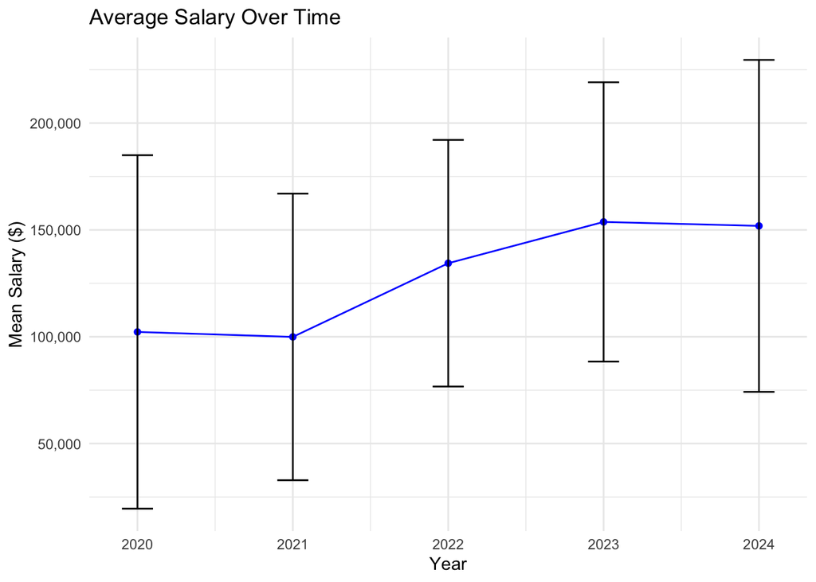

```r
library(ggplot2)
library(dplyr)
# Group by year and calculate the mean salary
salary_over_time <- df %>%
  group_by(work_year) %>%
  summarize(
    mean_salary = mean(salary_in_usd),
    sd_salary = sd(salary_in_usd)
  )

# Plotting
ggplot(salary_over_time, aes(x = work_year, y = mean_salary)) +
  geom_line(color = "blue") +
  geom_point(color = "blue") +
  geom_errorbar(aes(ymin = mean_salary - sd_salary, ymax = mean_salary + sd_salary), width = 0.2) +
  labs(
    title = "Average Salary Over Time",
    x = "Year",
    y = "Mean Salary ($)"
  ) +
  theme_minimal() +
  scale_y_continuous(labels = scales::comma)  # for readability use comma format
```

### RQ2: Salary by Company Size

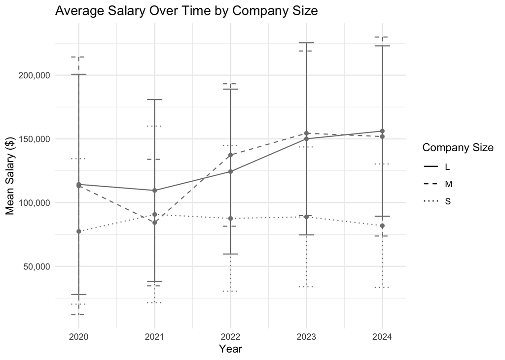

```r
library(ggplot2)
library(dplyr)
# Group by year and company size, and calculate the mean salary
salary_over_time <- df %>%
  group_by(work_year, company_size) %>%
  summarize(
    mean_salary = mean(salary_in_usd),
    sd_salary = sd(salary_in_usd)
  )
# Define colors and labels for each company size
company_size_labels <- c("small" = "Small", "medium" = "Medium", "large" = "Large")
company_size_colors <- c("small" = "blue", "medium" = "red", "large" = "yellow")


ggplot(salary_over_time, aes(x = work_year, y = mean_salary, color = company_size, linetype = company_size)) +
  geom_line() +
  geom_point() +
  geom_errorbar(aes(ymin = mean_salary - sd_salary, ymax = mean_salary + sd_salary), width = 0.2) +
  labs(
    title = "Average Salary Over Time by Company Size",
    x = "Year",
    y = "Mean Salary ($)",
    color = "Company Size",
    linetype = "Company Size"
  ) +
  scale_color_manual(values = company_size_colors, labels = company_size_labels) +
  scale_linetype_manual(values = c("solid", "dashed", "dotted"), labels = company_size_labels) +
  theme_minimal() +
  scale_y_continuous(labels = scales::comma)
```

After discussing the previous graphs in our final presentation I decided to make changes to the graphs to include median salary rather than mean. This will address issues of extreme variance and outliers while maintaining the same relationships. Additionally, we received feedback that displaying a standard deviation of one may not truly add to the information of the graph. Keeping in mind the importance of variability, I instead included IQR rather than standard deviation.

### RQ1 : Attempt 2

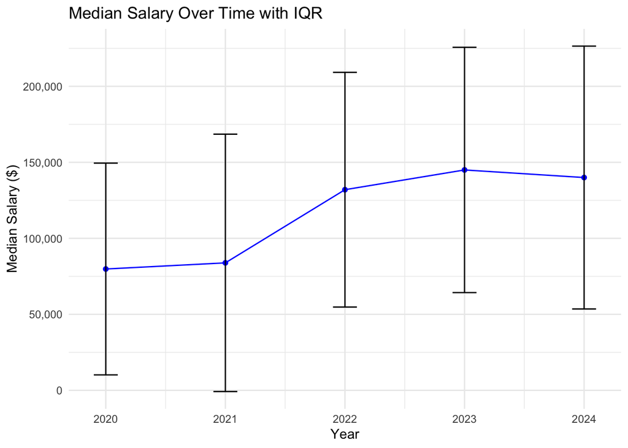

```r
# Group by year and calculate the median salary and IQR
salary_over_time <- df %>%
  group_by(work_year) %>%
  summarize(
    median_salary = median(salary_in_usd),
    q1 = quantile(salary_in_usd, 0.25),
    q3 = quantile(salary_in_usd, 0.75)
  )

# Calculate IQR
salary_over_time$IQR <- salary_over_time$q3 - salary_over_time$q1

# Plotting
ggplot(salary_over_time, aes(x = work_year, y = median_salary)) +
  geom_line(color = "blue") +
  geom_point(color = "blue") +
  geom_errorbar(aes(ymin = median_salary - IQR, ymax = median_salary + IQR), width = 0.2) +
  labs(
    title = "Median Salary Over Time with IQR",
    x = "Year",
    y = "Median Salary ($)"
  ) +
  theme_minimal() +
  scale_y_continuous(labels = scales::comma)  # for readability use comma format
```

#### Discussion:

The line graph illustrates the median salary in USD across five years, from 2020 to 2024. From 2020 to 2022, there is a consistent upward trend in median salaries, suggesting a period of salary growth likely influenced by factors such as industry expansion and heightened demand. However, around 2023 and 2024, the median salary appears to stabilize, indicating a potential saturation point or market equilibrium. This stabilization prompts questions for data scientists regarding the underlying causes, whether they stem from market dynamics, policy changes, or other factors. Additionally, the error bars at each data point represent the interquartile range (IQR), showcasing the variability in salaries around the median. Larger IQRs imply greater dispersion in salaries, offering valuable insights for further exploration by data science professionals. Overall, this graph provides a comprehensive view of salary trends over time, enabling analysis, prediction, and understanding of compensation dynamics within the dataset’s context.

### RQ2 : Attempt 2

```r
# Group by year and company size, and calculate the median salary and IQR
salary_over_time <- df %>%
  group_by(work_year, company_size) %>%
  summarize(
    median_salary = median(salary_in_usd),
    q1_salary = quantile(salary_in_usd, 0.25),
    q3_salary = quantile(salary_in_usd, 0.75)
  )
```

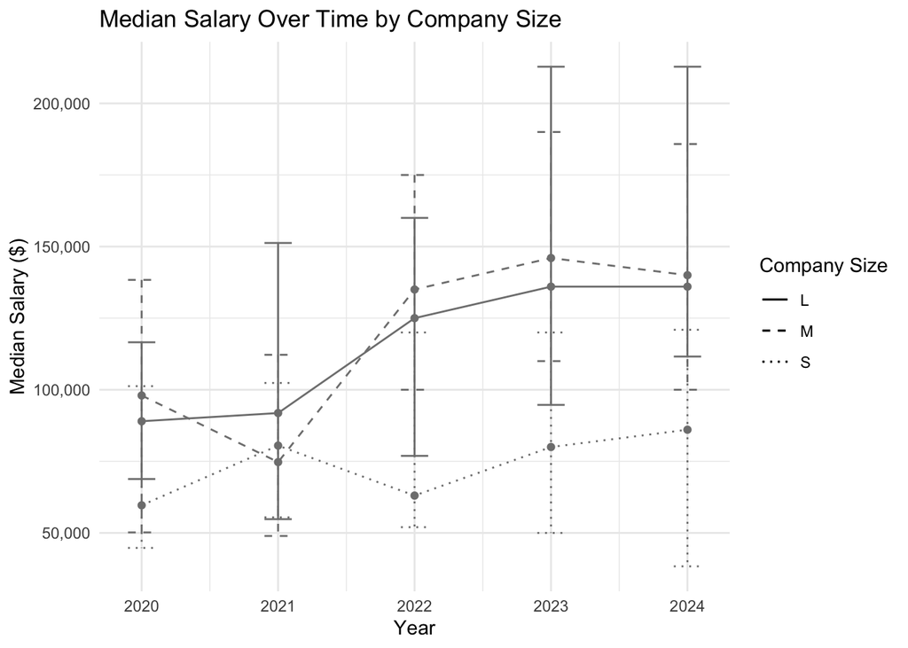

```r
# Define colors and labels for each company size
company_size_labels <- c("small" = "Small", "medium" = "Medium", "large" = "Large")
company_size_colors <- c("small" = "blue", "medium" = "red", "large" = "yellow")

# Create the plot
ggplot(salary_over_time, aes(x = work_year, y = median_salary, color = company_size, linetype = company_size)) +
  geom_line() +
  geom_point() +
  geom_errorbar(aes(ymin = q1_salary, ymax = q3_salary), width = 0.2) +  # Use IQR for error bars
  labs(
    title = "Median Salary Over Time by Company Size",
    x = "Year",
    y = "Median Salary ($)",
    color = "Company Size",
    linetype = "Company Size"
  ) +
  scale_color_manual(values = company_size_colors, labels = company_size_labels) +
  scale_linetype_manual(values = c("solid", "dashed", "dotted"), labels = company_size_labels) +
  theme_minimal() +
  scale_y_continuous(labels = scales::comma)
```

### RQ3: Salary by Company Location

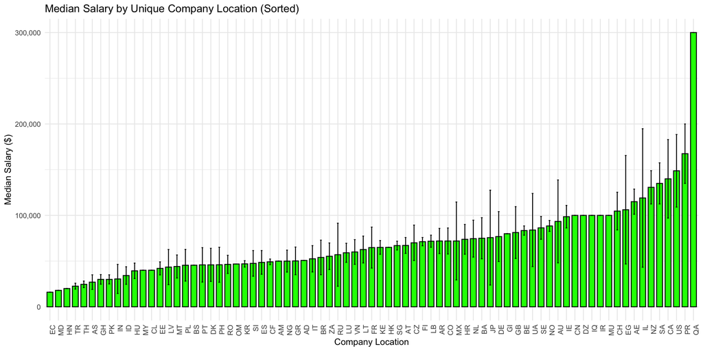

```r
# Load necessary libraries
library(ggplot2)
library(dplyr)

# Group by unique company_location and calculate the median salary, sorted by median_salary
salary_summary <- df %>%
  group_by(company_location) %>%
  summarize(
    median_salary = median(salary_in_usd),
    iqr_salary = IQR(salary_in_usd)  # Using IQR for error bars
  ) %>%
  arrange(median_salary)  # Sort by median salary

# Create the plot with sorted median salary and IQR error bars
ggplot(salary_summary, aes(x = reorder(company_location, median_salary), y = median_salary)) +
  geom_bar(stat = "identity", fill = "green", color = "black", width = 0.7) +
  geom_errorbar(aes(ymin = median_salary - iqr_salary/2, ymax = median_salary + iqr_salary/2), width = 0.2) +
  labs(
    title = "Median Salary by Unique Company Location (Sorted)",
    x = "Company Location",
    y = "Median Salary ($)"
  ) +
  theme_minimal() +
  theme(
    axis.text.x = element_text(angle = 90, hjust = 1)  # Rotate labels for better spacing
  ) +
  scale_y_continuous(labels = scales::comma)  # Prevent scientific notation by using comma format
```

#### Discussion:

The graph illustrates the median salary in USD for data science roles across various countries, sorted from lowest to highest. Qatar stands out with the highest median salary, reaching approximately $300,000. This significant salary suggests that data science roles in Qatar are among the most lucrative globally. The disparity between Qatar and other locations could be due to several factors, including the high demand for specialized skills, cost of living, or market dynamics in the region.

Meanwhile, the median salary in the United States, which is often considered a hub for technology and data science, is about $150,000. Although this value is significantly lower than Qatar’s, it is still relatively high compared to other countries on the graph. This distribution shows a wide range of salary levels for data science roles worldwide, indicating that geographic location is a significant factor in salary determination. Factors such as cost of living, market maturity, and regional demand for data science talent likely play critical roles in shaping these differences.

### RQ4: Salary by Experience

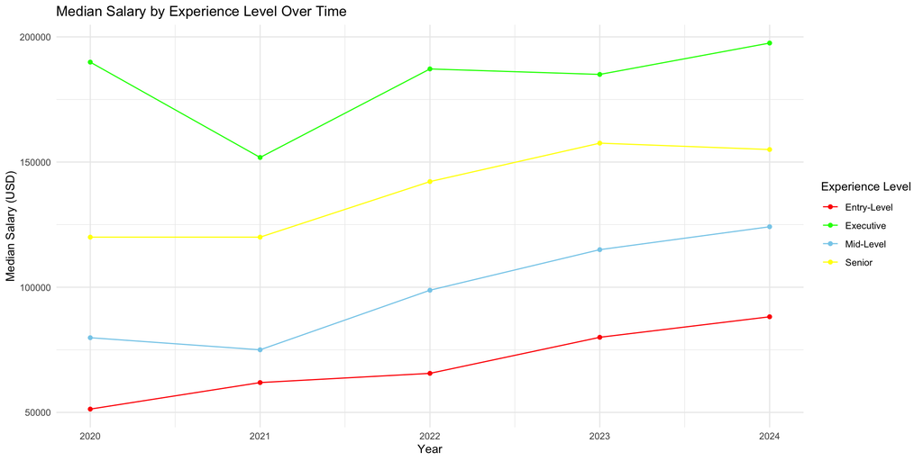

```r
# Load necessary libraries
library(ggplot2)
library(dplyr)

# Create consistent experience level naming
df <- df %>%
  mutate(experience_level = case_when(
    experience_level == "EN" ~ "Entry-Level",
    experience_level == "EX" ~ "Executive",
    experience_level == "SE" ~ "Senior",
    experience_level == "MI" ~ "Mid-Level",
    TRUE ~ experience_level  # Default if no match
  ))

# Calculate the median salary by work year and experience level
median_salary <- df %>%
  group_by(work_year, experience_level) %>%
  summarize(
    median_salary = median(salary_in_usd, na.rm = TRUE)  # Using median
  )
# Create a line plot with median salary over time by experience level
ggplot(median_salary, aes(x = work_year, y = median_salary, group = experience_level, color = experience_level)) +
  geom_line() +
  geom_point() +
  labs(
    title = "Median Salary by Experience Level Over Time",
    x = "Year",
    y = "Median Salary (USD)",
    color = "Experience Level"
  ) +
  scale_color_manual(values = c("red", "green", "skyblue", "yellow")) +
  theme_minimal()
```

#### Discussion:

The graph displays the median salary for data science roles across four experience levels—Entry-Level, Mid-Level, Senior, and Executive—from 2020 to 2024. As expected, the salaries increase with experience, with Entry-Level consistently earning the least and Executive earning the most. This trend remains consistent throughout the years plotted, indicating a clear progression in compensation as professionals advance in their careers. The gap between the different levels is significant.

Over the years, the graph shows a general upward trend in median salary across all experience levels, although the rate of increase varies. The difference between Mid-Level and Senior is notable, with Senior positions commanding a much higher salary, reflecting the added responsibility and expertise required at that level. The consistency in salary growth over the period indicates a robust market for data science roles, with experienced professionals enjoying significant compensation advantages. Despite minor fluctuations, the overall upward trajectory suggests a positive outlook for career progression in the data science field.

### RQ5: Salary by Job Title

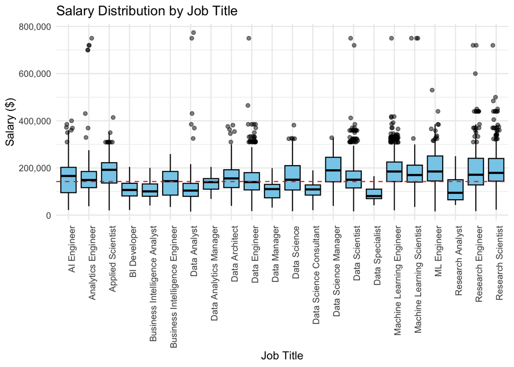

```r
library(ggplot2)
library(dplyr)
library(tidyr)

# Calculate unique job titles with count > 50
unique_job_titles <- df %>%
  filter(!is.na(job_title)) %>%  # Filter out missing values
  group_by(job_title) %>%
  summarize(job_count = n()) %>%
  filter(job_count > 50) %>%
  pull(job_title)  # Extract unique job titles as vector

# Filter the original dataframe for plotting
df_filtered <- df %>%
  filter(!is.na(job_title)) %>%  # Filter out missing values
  filter(job_title %in% unique_job_titles)

# Create the plot using the filtered dataframe
ggplot(df_filtered, aes(x = job_title, y = salary_in_usd)) +
  geom_boxplot(fill = "skyblue", color = "black", outlier.shape = NA) +  # Use geom_boxplot to create boxplots
  geom_jitter(data = df_filtered %>% filter(salary_in_usd < quantile(salary_in_usd, 0.25) - 1.5*IQR(salary_in_usd) | salary_in_usd > quantile(salary_in_usd, 0.75) + 1.5*IQR(salary_in_usd)), width = 0.2, color = "black", alpha = 0.5) +
  geom_hline(yintercept = median(df_filtered$salary_in_usd), color = "red", linetype = "dashed") +  # Add a dashed line for median
  labs(
    title = "Salary Distribution by Job Title",
    x = "Job Title",
    y = "Salary ($)"
  ) +
  theme_minimal() +
  theme(
    axis.text.x = element_text(angle = 90, hjust = 1)  # Rotate labels for better spacing
  ) +
  scale_y_continuous(labels = scales::comma)  # Prevent scientific notation by using comma format
```

### RQ6: Salary by Remote Ratio and Company Size

Initially, we looked solely are remote ratio and its relationship to salary, but upon receiving feedback from the professor, we realized that company size may have an influence on remote ratio policies. Because of this, we decided to examine the interaction of remote ratio, company size, and salary.

```r
# Convert remote_ratio to factor with specified levels
df$remote_ratio <- factor(df$remote_ratio, levels = c(0, 50, 100))
df$company_size <- factor(df$company_size, levels = c("S", "M", "L"))

# Print summary of counts for each level of company_size
cat("Counts for each level of company_size:\n")
```

```
## Counts for each level of company_size:
```

```r
print(summary(df$company_size))
```

```
##     S     M     L
##   178 12594   958
```

```r
# Print summary of counts for each level of remote_ratio
cat("\nCounts for each level of remote_ratio:\n")
```

```
##
## Counts for each level of remote_ratio:
```

```r
print(summary(df$remote_ratio))
```

```
##    0   50  100
## 9006  241 4483
```

#### Discussion:

As shown in the table above, there were a significantly larger number of medium-sized companies in the database. We were interested in looking at the count of in-person, hybrid, and remote jobs for each company size, but due to the very different scales we decided to display the data in a 100% stacked bar chart, as shown in the plot below.

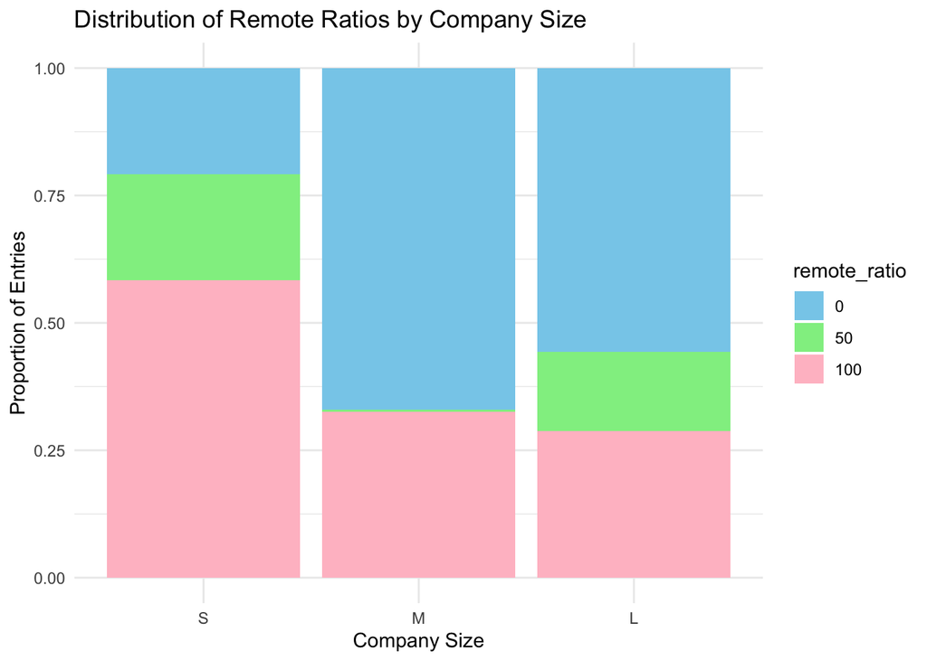

```r
# Load necessary library
library(ggplot2)
library(scales)
library(dplyr)

# Summarize data by company_size and remote_ratio
summary_df <- df %>%
  group_by(company_size, remote_ratio) %>%
  summarize(count = n()) %>%
  mutate(prop = count / sum(count))
# Create the plot
ggplot(summary_df, aes(x = company_size, y = prop, fill = remote_ratio)) +
  geom_bar(stat = "identity", position = "stack") +
  labs(
    title = "Distribution of Remote Ratios by Company Size",
    x = "Company Size",
    y = "Proportion of Entries"
  ) +
  scale_fill_manual(values = c("skyblue", "lightgreen", "pink")) +  # Custom color palette
  theme_minimal()
```

#### Discussion:

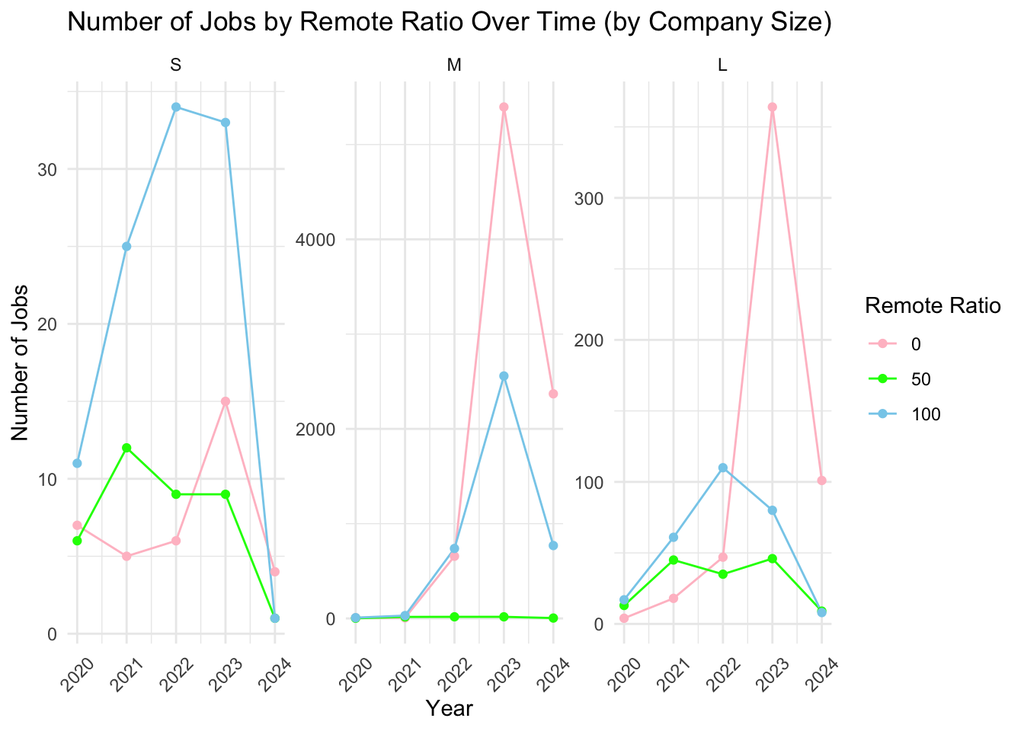

```r
# Calculate count of jobs for each combination of time, remote_ratio, and company_size
job_counts <- aggregate(job_title ~ work_year + remote_ratio + company_size, data = df, FUN = length)

# Plot with faceting by company_size and free y-axis scales
ggplot(job_counts, aes(x = work_year, y = job_title, group = remote_ratio, color = remote_ratio)) +
  geom_line() +
  geom_point() +
  labs(
    title = "Number of Jobs by Remote Ratio Over Time (by Company Size)",
    x = "Year",
    y = "Number of Jobs",
    color = "Remote Ratio"
  ) +
  scale_color_manual(values = c("pink", "green", "skyblue")) +
  theme_minimal() +
  facet_wrap(~ company_size, scales = "free_y") +  # Facet by company_size variable with free y-axis scales
  theme(axis.text.x = element_text(angle = 45, hjust = 0.5, vjust = 0.5))  # Rotate y-axis labels vertically
```

#### Discussion:

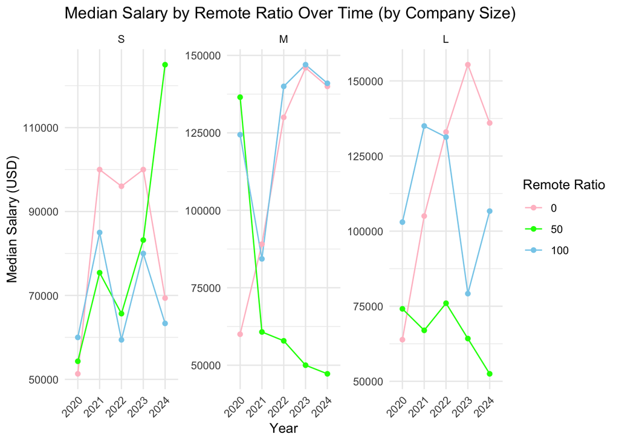

```r
# Convert time to factor if it's not already
df$work_year <- as.factor(df$work_year)
df$work_year <- factor(df$work_year, levels = c("2020", "2021", "2022", "2023", "2024"))

# Calculate average salary for each combination of time, remote_ratio, and company_size
average_salary <- aggregate(salary_in_usd ~ work_year + remote_ratio + company_size, data = df, FUN = median)

# Plot with faceting by company_size and adjusted facet width
ggplot(average_salary, aes(x = work_year, y = salary_in_usd, group = remote_ratio, color = remote_ratio)) +
  geom_line() +
  geom_point() +
  labs(
    title = "Median Salary by Remote Ratio Over Time (by Company Size)",
    x = "Year",
    y = "Median Salary (USD)",
    color = "Remote Ratio"
  ) +
  scale_color_manual(values = c("pink", "green", "skyblue")) +
  theme_minimal() +
  facet_wrap(~ company_size, scales = "free_y") +  # Facet by company_size variable with free y-axis scales
  theme(axis.text.x = element_text(angle = 45, hjust = 1))
```

#### Discussion:

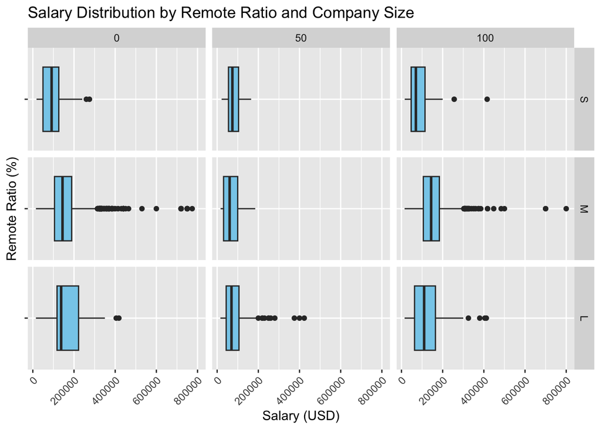

```r
# Create the horizontally rotated box plot with angled x-axis labels, no legend, and custom colors
ggplot(df, aes(x = salary_in_usd, y = "", fill = remote_ratio)) +
  geom_boxplot() +
  facet_grid(company_size ~ remote_ratio, scales = "free_y") +
  labs(
    title = "Salary Distribution by Remote Ratio and Company Size",
    x = "Salary (USD)",
    y = "Remote Ratio (%)"
  ) +
  scale_x_continuous(labels = function(x) format(x, scientific = FALSE)) +
  scale_fill_manual(values = c("skyblue", "skyblue", "skyblue")) +
  theme(axis.text.x = element_text(angle = 45, hjust = 1),
        legend.position = "none")  # Remove legend
```

## Conclusion

In conclusion, our examination of median salary trends in the data science domain has revealed noteworthy patterns and areas for further exploration. The consistent upward trajectory in median salaries from 2020 to 2022 suggests a period of substantial growth, potentially fueled by factors such as expanding industries and heightened demand for specialized skills. However, the stabilization observed around 2023 and 2024 prompts inquiries into potential saturation points or shifts in market dynamics. Furthermore, the disparities in median salaries across different company sizes and experience levels underscore the nuanced nature of compensation dynamics within the field.

Moving forward, future research endeavors could focus on several key areas. Firstly, delving deeper into the changes in salary trends over time, particularly during pivotal periods such as the pandemic years, could provide valuable insights into evolving compensation dynamics and their underlying drivers. Additionally, exploring the impact of additional factors, such as geographical location or educational background, on salary variations could offer a more comprehensive understanding of the factors influencing compensation levels in data science roles.

Moreover, investigating the interaction between remote work policies, company size, and salary could shed light on emerging trends in remote work practices and their implications for compensation strategies. By examining how these factors intersect and influence each other, we can better understand the evolving landscape of work arrangements and their impact on salary structures.

Overall, our findings highlight the need for ongoing research to deepen our understanding of salary trends in the data science field. By addressing these questions, we can inform strategic decision-making and contribute to the development of more equitable and competitive compensation practices within the industry.